# **Counting Sort**

### **Panduan Langkah demi Langkah**

Sebelum kita mengimplementasikan algoritma Counting Sort dalam bahasa pemrograman, mari kita jalankan secara manual sebuah array pendek, hanya untuk mendapatkan gambaran dasarnya.

- **Langkah 1:** Kita mulai dengan array yang belum diurutkan.

myArray = [ 2, 3, 0, 2, 3, 2]

- **Langkah 2:** Kita membuat array lain untuk menghitung jumlah setiap nilai. Array ini memiliki 4 elemen, untuk menyimpan nilai 0 hingga 3.

myArray = [ 2, 3, 0, 2, 3, 2] countArray = [ 0, 0, 0, 0]

- **Langkah 3:** Sekarang mari kita mulai menghitung. Elemen pertama adalah 2, jadi kita harus menambah elemen array penghitung pada indeks 2.

myArray = [ 2, 3, 0, 2, 3, 2] countArray = [ 0, 0, 1, 0]

- **Langkah 4:** Setelah menghitung suatu nilai, kita dapat menghapusnya, dan menghitung nilai berikutnya, yaitu 3.

myArray = [ 3, 0, 2, 3, 2] countArray = [ 0, 0, 1, 1]

- **Langkah 5:** Nilai berikutnya yang kita hitung adalah 0, jadi kita menambah indeks 0 pada array penghitung.

myArray = [ 0, 2, 3, 2] countArray = [ 1, 0, 1, 1]

- **Langkah 6:** Kita lanjutkan seperti ini sampai semua nilai dihitung.

myArray = [ ] countArray = [ 1, 0, 3, 2]

- ***Langkah 7:** Sekarang kita akan membuat ulang elemen-elemen dari array awal, dan kita akan melakukannya sedemikian rupa sehingga elemen-elemen tersebut diurutkan dari terendah ke tertinggi.

Elemen pertama dalam array penghitung memberi tahu kita bahwa kita memiliki 1 elemen dengan nilai 0. Jadi kita menambahkan 1 elemen dengan nilai 0 ke dalam array, dan kita mengurangi elemen pada indeks 0 dalam array penghitung dengan 1.

myArray = [ 0] countArray = [ 0, 0, 3, 2]

- **Langkah 8:** Dari array penghitung, kita melihat bahwa kita tidak perlu membuat elemen apa pun dengan nilai 1.

myArray = [ 0] countArray = [ 0, 0, 3, 2]

- **Langkah 9:** Kita menambahkan 3 elemen dengan nilai 2 ke akhir array. Dan saat kita membuat elemen-elemen ini, kita juga mengurangi array penghitung pada indeks 2.

myArray = [ 0, 2, 2, 2] countArray = [ 0, 0, 0, 2]

- **Langkah 10:** Terakhir, kita harus menambahkan 2 elemen dengan nilai 3 di akhir array.

myArray = [0, 2, 2, 2, 3, 3] countArray = [ 0, 0, 0, 0]

Akhirnya! Lariknya sudah diurutkan.

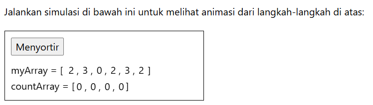

### **Mengimplementasikan Counting Sort di Python**

Untuk mengimplementasikan algoritma Counting Sort dalam program Python, kita membutuhkan:

1. Sebuah array berisi nilai-nilai yang akan diurutkan.
2. Metode 'countingSort' yang menerima array bilangan bulat.
3. Sebuah array di dalam metode untuk menyimpan jumlah nilai.
4. Sebuah perulangan di dalam metode yang menghitung dan menghapus nilai, dengan menambah elemen dalam larik penghitung.
5. Sebuah perulangan di dalam metode yang membuat ulang array dengan menggunakan array penghitung, sehingga elemen-elemennya muncul dalam urutan yang benar.

**Satu hal lagi:** Kita perlu mencari tahu nilai tertinggi dalam array tersebut, agar array penghitung dapat dibuat dengan ukuran yang tepat. Misalnya, jika nilai tertinggi adalah 5, array penghitung harus memiliki total 6 elemen, agar dapat menghitung semua kemungkinan bilangan bulat non-negatif 0, 1, 2, 3, 4, dan 5.

Kode yang dihasilkan akan terlihat seperti ini:

```python
# ContohDapatkan server Python Anda sendiri
# Menggunakan algoritma Counting Sort dalam program Python:

def countingSort(arr):
  max_val = max(arr)
  count = [0] * (max_val + 1)

  while len(arr) > 0:
    num = arr.pop(0)
    count[num] += 1

  for i in range(len(count)):
    while count[i] > 0:
      arr.append(i)
      count[i] -= 1

  return arr

mylist = [4, 2, 2, 6, 3, 3, 1, 6, 5, 2, 3]
mysortedlist = countingSort(mylist)
print(mysortedlist)
```

## Kompleksitas Waktu Pengurutan Hitungan

Kecepatan algoritma Counting Sort berjalan bergantung pada rentang nilai yang mungkin. k dan jumlah nilai N .

Secara umum, kompleksitas waktu untuk Counting Sort adalah HAI ( N + k ) .

Dalam skenario terbaik, rentang nilai berbeda yang mungkin terjadi adalah... k sangat kecil dibandingkan dengan jumlah nilai. N dan Counting Sort memiliki kompleksitas waktu HAI ( N ) .

Namun dalam skenario terburuk, rentang nilai berbeda yang mungkin terjadi k ukurannya sangat besar dibandingkan dengan jumlah nilai N dan Counting Sort dapat memiliki kompleksitas waktu HAI ( N 2 ) atau bahkan lebih buruk.

Grafik di bawah ini menunjukkan seberapa besar kompleksitas waktu untuk algoritma Counting Sort dapat bervariasi.

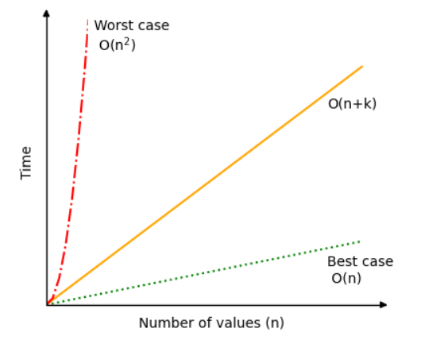

Seperti yang telah disebutkan sebelumnya: jika angka yang akan diurutkan memiliki nilai yang sangat bervariasi (besar) k ), dan hanya ada sedikit angka yang perlu diurutkan (kecil) N ), algoritma Counting Sort tidak efektif.

# **Counting Sort GFG**

Counting Sort adalah algoritma pengurutan yang tidak berbasis perbandingan . Algoritma ini sangat efisien ketika rentang nilai input kecil dibandingkan dengan jumlah elemen yang akan diurutkan.

- Ide dasar di balik Counting Sort adalah menghitung frekuensi setiap elemen unik dalam array input dan menggunakan informasi tersebut untuk menempatkan elemen-elemen tersebut pada posisi yang benar sesuai urutannya.
- Ini berfungsi dengan baik ketika rentang elemen input kecil dan sebanding dengan ukuran array. Misalnya, untuk input [1, 4, 0, 2, 1, 1], ukuran array adalah 6 dan rentang elemennya dari 0 hingga 4.
- Jika rentang array input berukuran lebih besar dari n Log n, di mana n adalah ukuran array, maka kita dapat mengurutkan array dengan lebih baik menggunakan algoritma pengurutan berbasis perbandingan standar seperti Merge Sort.

**Algoritma Pengurutan Hitungan**

- Deklarasikan array hitungan cntArr[] dengan ukuran max(arr[])+1 dan inisialisasi dengan 0 .
- Telusuri array input arr[] dan petakan setiap elemen arr[] sebagai indeks array cntArr[] , yaitu, jalankan cntArr[arr[i]]++ untuk 0 <= i < N .
- Hitung jumlah prefiks pada setiap indeks cntArr[] .
- Buat array ans[] dengan ukuran N.
- Telusuri array arr[] dari akhir dan perbarui ans[ cntArr[ arr[i] ] - 1] = arr[i] . Juga, perbarui cntArr [ arr[i] ] = cntArr[ arr[i] ]- - .

**Mengapa kita menghitung Jumlah Awalan?**

Kita bisa saja menghitung kemunculan semua elemen dan satu per satu memasukkannya ke dalam array keluaran, tetapi kita menghitung jumlah awalan untuk mencapai stabilitas dalam algoritma. Perhatikan bahwa, setelah membangun jumlah awalan cntArr[], kita menelusuri array dari ujung kanan untuk memastikan bahwa kemunculan terakhir berpindah ke posisi yang benar terakhir dalam array yang diurutkan.

**Cara Kerja Penghitungan dan Pengurutan**

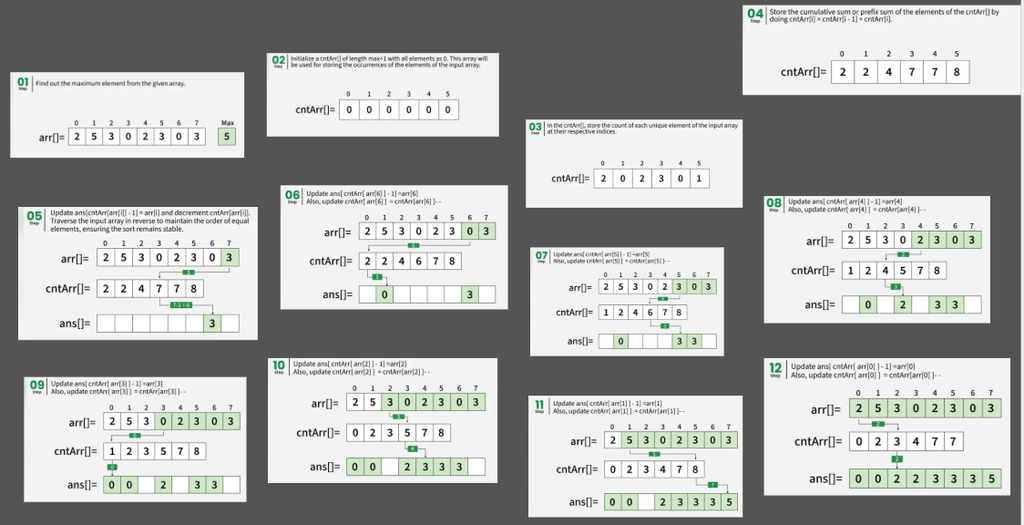

```python
def count_sort(arr):
    if not arr:
        return []

    n = len(arr)
    maxval = max(arr)

    # create and initialize cntArr
    cntArr = [0] * (maxval + 1)

    # count frequency of each element
    for v in arr:
        cntArr[v] += 1

    # compute prefix sums
    for i in range(1, maxval + 1):
        cntArr[i] += cntArr[i - 1]

    # build output array
    ans = [0] * n
    # iterate in reverse to keep it stable
    for i in range(n - 1, -1, -1):
        v = arr[i]
        ans[cntArr[v] - 1] = v
        cntArr[v] -= 1

    return ans


if __name__ == "__main__":
    arr = [2, 5, 3, 0, 2, 3, 0, 3]
    ans = count_sort(arr)
    print(ans)
```

**Analisis Kompleksitas Pengurutan Hitungan (Counting Sort):**

- Kompleksitas Waktu : O(N+M) dalam semua kasus, di mana N dan M masing-masing adalah ukuran inputArray[] dan countArray[] .
- Ruang Tambahan: O(N+M), di mana N dan M adalah ruang yang ditempati oleh outputArray[] dan countArray[] masing-masing.

**Keunggulan Penghitungan Sortir:**

- Counting sort umumnya bekerja lebih cepat daripada semua algoritma pengurutan berbasis perbandingan, seperti merge sort dan quicksort, jika rentang input sebanding dengan jumlah input.
- Algoritma Stabil

**Kelemahan Pengurutan Berdasarkan Jumlah:**

- Tidak berfungsi pada nilai desimal.
- Tidak efisien jika rentang nilai yang akan diurutkan sangat besar.
- Ini bukan algoritma pengurutan langsung (in-place) , algoritma ini menggunakan ruang tambahan untuk mengurutkan elemen-elemen array.

**Penerapan Metode Pengurutan Berdasarkan Jumlah:**

- Ini adalah algoritma yang umum digunakan untuk kasus-kasus di mana kita memiliki item dengan rentang terbatas. Misalnya, mengurutkan siswa berdasarkan nilai, mengurutkan acara berdasarkan waktu, hari, bulan, tahun, dan lain sebagainya.
- Ini digunakan sebagai subrutin dalam Radix Sort.
- Konsep pengurutan berdasarkan jumlah digunakan dalam Bucket Sort untuk membagi elemen ke dalam beberapa wadah yang berbeda.

# **LATIHAN CODE**

**Soal 1: Counting Sort Dasar dengan Penjelasan Instruksi: Buatlah program yang mengurutkan array menggunakan array hitung (count array).**

```python
def counting_sort(arr):
    if not arr: return []
    max_val = max(arr)
    # Array untuk menampung frekuensi
    count = [0] * (max_val + 1)

    for num in arr:
        count[num] += 1

    # Membangun kembali array yang terurut
    sorted_arr = []
    for num in range(max_val + 1):
        sorted_arr.extend([num] * count[num])
    return sorted_arr

data = [4, 2, 2, 8, 3, 3, 1]
print(f"Data Awal: {data}")
print(f"Data Terurut: {counting_sort(data)}")
```

**Soal 2: Visualisasi Frekuensi (Hitung Per-Angka) Instruksi: Tampilkan berapa kali setiap angka muncul sebelum diurutkan.**

```python
data = [1, 2, 3, 2, 1, 4, 1]
count = {}
for x in data:
    count[x] = count.get(x, 0) + 1

print("Statistik kemunculan:")
for num, freq in sorted(count.items()):
    print(f"Angka {num} muncul {freq} kali")
```

**Soal 3: Cumulative Count (Logika Penentuan Posisi) Instruksi: Lakukan proses akumulasi pada array hitung untuk menentukan posisi akhir setiap elemen.**

```python
data = [1, 4, 1, 2, 7, 5, 2]
max_val = max(data)
count = [0] * (max_val + 1)

for x in data: count[x] += 1
# Proses akumulasi
for i in range(1, len(count)):
    count[i] += count[i-1]

print(f"Hasil akumulasi posisi: {count}")
```

**Soal 4: Stable Counting Sort (Menggunakan Array Output) Instruksi: Implementasikan algoritma Counting Sort yang stabil dengan membuat array output berukuran sama dengan data.**

```python
def stable_counting_sort(arr):
    n = len(arr)
    max_val = max(arr)
    count = [0] * (max_val + 1)
    output = [0] * n

    for x in arr: count[x] += 1
    for i in range(1, len(count)): count[i] += count[i-1]

    # Isi output dari kanan ke kiri untuk kestabilan
    for i in range(n - 1, -1, -1):
        output[count[arr[i]] - 1] = arr[i]
        count[arr[i]] -= 1
    return output

print(f"Stable Sort: {stable_counting_sort([1, 4, 1, 2, 7, 5, 2])}")
```

**Soal 5: Counting Sort untuk Data Negatif Instruksi: Modifikasi algoritma agar bisa menangani angka negatif dengan cara menggeser (offset) nilai minimum ke nol.**

```python
def counting_sort_negatif(arr):
    min_val, max_val = min(arr), max(arr)
    range_val = max_val - min_val + 1
    count = [0] * range_val

    for x in arr: count[x - min_val] += 1
    # ... (lanjutkan rekonstruksi)
    sorted_arr = []
    for i, freq in enumerate(count):
        sorted_arr.extend([i + min_val] * freq)
    return sorted_arr

print(f"Dengan Angka Negatif: {counting_sort_negatif([-2, 1, 0, -5, 3])}")
```

**Soal 6: Menghitung Rentang (Range) Data secara Manual Instruksi: Temukan rentang (min dan max) tanpa fungsi bawaan min() dan max().**

```python
data = [5, 3, 8, 1, 9]
min_v = max_v = data[0]
for x in data:
    if x < min_v: min_v = x
    if x > max_v: max_v = x
print(f"Rentang data: {min_v} sampai {max_v}")
```

**soal 7: Counting Sort untuk Array String (Karakter) Instruksi: Urutkan string berdasarkan nilai ASCII karakternya menggunakan Counting Sort.**

```python
def sort_chars(s):
    arr = [ord(c) for c in s]
    sorted_arr = counting_sort(arr) # Gunakan fungsi dari soal 1
    return "".join(chr(x) for x in sorted_arr)

print(f"Urut karakter: {sort_chars('madura')}")
```

**Soal 8: Analisis Complexity secara Kode Instruksi: Buat simulasi yang menghitung berapa kali operasi dilakukan dalam Counting Sort.**

```python
data = [1, 2, 3, 2, 1]
ops = 0
# Counting
for x in data: ops += 1
# Accumulating
for i in range(len(data)): ops += 1
print(f"Total operasi: {ops}")
```

**Soal 10: Full Implementation dengan Kelas/Fungsi Terstruktur (Untuk Demo UAS) Instruksi: Buat satu fungsi yang komprehensif, mencakup perhitungan frekuensi, akumulasi, dan penempatan ke array output.**

```python
def comprehensive_counting_sort(arr):
    if not arr: return []
    # 1. Menentukan rentang
    min_val, max_val = min(arr), max(arr)
    range_val = max_val - min_val + 1
    count = [0] * range_val
    output = [0] * len(arr)

    # 2. Menghitung frekuensi
    for x in arr: count[x - min_val] += 1

    # 3. Akumulasi posisi
    for i in range(1, len(count)): count[i] += count[i-1]

    # 4. Membangun output
    for i in range(len(arr) - 1, -1, -1):
        output[count[arr[i] - min_val] - 1] = arr[i]
        count[arr[i] - min_val] -= 1
    return output

print(f"Final Result: {comprehensive_counting_sort([10, 4, 10, 2, 2, 5])}")
```